# Homework 1

Yuxin

## Problem 1

## create data frame

```r
problem1_df = tibble(
  vec_runiform = runif(10,min=0,max=5),
  vec_logical = output_column(vec_runiform > 2),
  vec_character = c("My","name","is","Yuxin","I","love","Data","Science","a","lot"),
  vec_factor = factor(c("male", "male", "female", "female","male","female","male","female","male","male"))
)
problem1_df
```

```
## # A tibble: 10 x 4
##    vec_runiform vec_logical vec_character vec_factor
##           <dbl> <lgl>       <chr>         <fct>
##  1        2.21  TRUE        My            male
##  2        3.19  TRUE        name          male
##  3        2.11  TRUE        is            female
##  4        3.95  TRUE        Yuxin         female
##  5        0.767 FALSE       I             male
##  6        2.15  TRUE        love          female
##  7        3.45  TRUE        Data          male
##  8        4.58  TRUE        Science       female
##  9        1.53  FALSE       a             male
## 10        2.95  TRUE        lot           male
```

- The mean of the numerical vector is 2.6888937
- The mean of the logical vector is 0.8
- The mean of the character vector is NA
- The mean of the factor vector is NA

I can find the mean of the numerical and logical vector, and the result of the mean of character and factor vector is not working. This happened due to that mean function in R find the arithmetic mean of the variable. Only variable with a number will make sense under mean function.

## Convert variables 1

```r
as.numeric(problem1_df$vec_logical)
as.numeric(problem1_df$vec_character)
as.numeric(problem1_df$vec_factor)
```

[output not shown]

After I apply the “as.numeric” function to the logical, character and factor variables, I have the numerical output of logical and factor variables, and invalid output of character variable. In my example, I have 1 for true, 0 for false, 2 for male and 1 for female.

## Convert variables 2

```r
as.numeric(as.factor(problem1_df$vec_character))
```

```
##  [1]  7  8  4 10  3  6  2  9  1  5
```

```r
as.numeric(as.character(problem1_df$vec_factor))
```

```
##  [1] NA NA NA NA NA NA NA NA NA NA
```

I obtain numerical results after convert my character variable from character to factor to numeric. I obtain invalid result after convert my factor variable from factor to character to numeric.

## Problem 2

## create data frame

```r
problem2_df = tibble(
  x = rnorm(1000),
  y= rnorm(1000),
  vec_indicator = output_column (x+y > 0),
  vec_numeric  = as.numeric(vec_indicator),
  vec_factor = as.factor(vec_indicator))
problem2_df
```

```
## # A tibble: 1,000 x 5
##          x       y vec_indicator vec_numeric vec_factor
##      <dbl>   <dbl> <lgl>               <dbl> <fct>
##  1 -0.0234  0.545  TRUE                    1 TRUE
##  2  0.871  -2.28   FALSE                   0 FALSE
##  3  0.755  -1.77   FALSE                   0 FALSE
##  4 -0.475  -0.842  FALSE                   0 FALSE
##  5 -0.779  -2.00   FALSE                   0 FALSE
##  6  1.33   -1.58   FALSE                   0 FALSE
##  7 -0.463   1.56   TRUE                    1 TRUE
##  8 -0.389   0.0598 FALSE                   0 FALSE
##  9  0.0229  1.41   TRUE                    1 TRUE
## 10  0.817  -1.90   FALSE                   0 FALSE
## # ... with 990 more rows
```

- The size,mean,and median of the x vector is 1000, 0.0100487,0.0477768
- The size,mean,and median of the y vector is 1000, 0.023712,0.003227
- The size,mean,and median of the logical vector is 1000, 0.516,1
- The size,mean,and median of the numeric vector is 1000, 0.516,1
- The size,mean,and median of the factor vector is 1000, `NA`,`NA`
- The proportion of cases for which the logcial vector is TRUE is 0.516

## plot

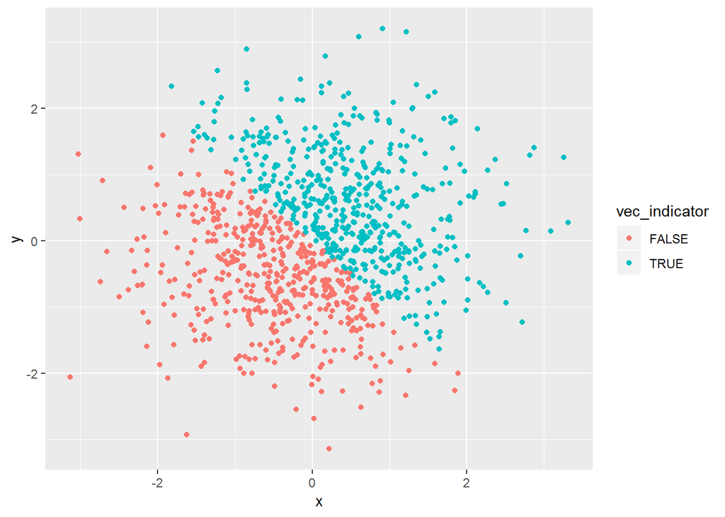

```r
scatterplot1 <- ggplot(problem2_df, aes(x = x, y = y,color=vec_indicator)) + geom_point()
scatterplot2 <-ggplot(problem2_df, aes(x = x, y = y,color=vec_numeric)) + geom_point()
scatterplot3 <-ggplot(problem2_df, aes(x = x, y = y,color=vec_factor)) + geom_point()
scatterplot1
```

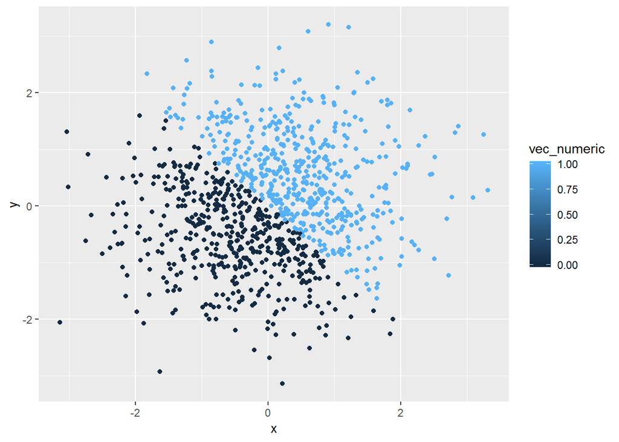

```r
scatterplot2
```

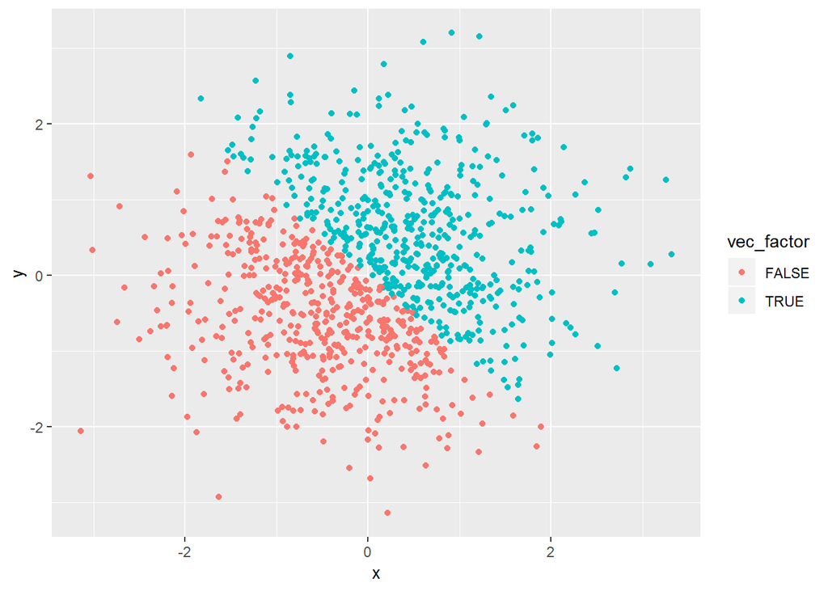

```r
scatterplot3
```

```r
ggsave("scatterplot1.png",plot=scatterplot1)
```

In the plot, we can observe that, in all three scatterplots, two different colors occupied roughly half of the plots, splitting by the upper-left to the down-right diagonal. This indicates that we have an almost same probability of True and False cases in the logical vector.